# Market Analysis: Problem Set 1

The data set **chile.dta** is a Stata file containing a panel of Chilean firms from the annual manufacturing census Encuesta Nacional Industrial Anual (ENIA) run by Chile’s national statistical institute, Instituto Nacional de Estadisticas (INE). The panel covers the period 1979–1996 and only includes data for firms in the food industry (CIIU code 311). Each observation is a year-firm combination. The data have already been cleaned up and the relevant variables constructed.

The data includes: gross output, labor, capital stock, energy inputs, material inputs, and investment. All variables except labor are measured in 1985 Chilean pesos. Labor is a wage-weighted aggregate of white- and blue-collar employees measured in blue-collar person-year equivalents. In addition, a firm id and year are included.

**Submission guidelines:**

1. Submission requires downloading and saving your ipynb file as .html file with the filename, studentID-studentName. For example, 407510073-束良鴻.
2. Removing all irrelevant code blocks.
3. Email the html file to your TA. (E-mail address: p4896p4896@gmail.com)
4. Failing to submit in a correct format will result in a reduction of **20 points**.
5. Deadline: 4/7 Thur. 2 p.m.
6. No late submission will be accepted.

You need to run the following code block first to import necessary packages.

```python
import pandas as pd

from matplotlib import pyplot as plt

%matplotlib inline
```

Read **chile.dta** as a dataframe called **chile**. (Hint: It is a dta file not csv.)

```python
chile = pd.read_stata('chile.dta')
```

Please answer the following questions. Total points is 110. Good Luck!

**Q1** How many unique firms are included in this dataset? (10 pts)

```python
chile['id'].nunique()
```

```
2673
```

**Q2** What is the average duration for firms in this dataset? Also, what is the longest and shortest duration? (Hint: **transform** method would be useful.) (30 pts)

```python
average = chile.groupby('id')["year"].max() - chile.groupby('id')["year"].min() + 1
```

```python
average.mean()
```

```
7.807706696595585
```

```python
average.max()
```

```
18
```

```python
average.min()
```

```
1
```

**Q3** Show me the correlation matrix for gross output, labor, capital stock, energy inputs, material inputs, and investment. (20 pts, inclusion of irrelevant variables will only get half of the points.)

```python
chile[['routput','totlab','renerg','realmats','rcapstock','rinvest']].corr()
```

|  | routput | totlab | renerg | realmats | rcapstock | rinvest |
| --- | --- | --- | --- | --- | --- | --- |
| routput | 1.000000 | 0.738028 | 0.627440 | 0.958528 | 0.644604 | 0.397732 |
| totlab | 0.738028 | 1.000000 | 0.545575 | 0.688555 | 0.606957 | 0.393596 |
| renerg | 0.627440 | 0.545575 | 1.000000 | 0.572255 | 0.624652 | 0.338236 |
| realmats | 0.958528 | 0.688555 | 0.572255 | 1.000000 | 0.582926 | 0.361691 |
| rcapstock | 0.644604 | 0.606957 | 0.624652 | 0.582926 | 1.000000 | 0.502015 |
| rinvest | 0.397732 | 0.393596 | 0.338236 | 0.361691 | 0.502015 | 1.000000 |

**Q4** Calculating the industry average for each year, and plot time series plots for gross output and labor. (20 pts)

```python
chile.groupby('year')['id'].nunique()
```

```
year
1979    1345
1980    1317
1981    1237
1982    1178
1983    1140
1984    1137
1985    1146
1986    1100
1987    1123
1988    1115
1989    1077
1990    1075
1991    1093
1992    1122
1993    1115
1994    1106
1995    1101
1996    1203
Name: id, dtype: int64
```

```python
output = chile.groupby('year')['routput'].sum()
labor = chile.groupby('year')['totlab'].sum()
```

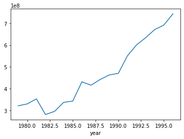

```python
output.plot()
```

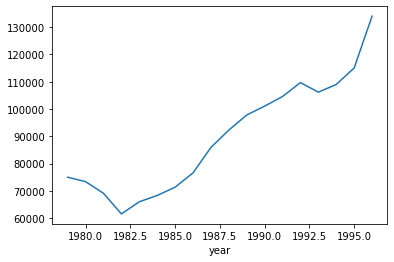

```python
labor.plot()
```

**Q5** Calculate the numbers of entries and exits for each year and draw time series plots. Ignore the 1979 for entry and 1996 for exit. (Hint: It would be helpful to define starting year and ending year for each firm.) (30 pts)

```python
entry = chile.groupby('id')["year"].min()
entry = pd.DataFrame(entry, columns=['year'])
entry = entry.loc[entry.year!=1979]
exit = chile.groupby('id')["year"].max()
exit = pd.DataFrame(exit, columns=['year'])
exit = exit.loc[exit.year!=1996]
```

```python
df1 = pd.DataFrame(chile.year.drop_duplicates())
df2 = pd.DataFrame(chile.year.drop_duplicates())
df1['entry']=df['year'].apply(lambda x : entry[entry['year']==x].shape[0])
df2['exit']=df['year'].apply(lambda x : exit[exit['year']==x].shape[0])
```

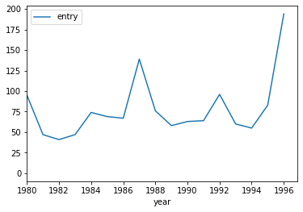

```python
df1.plot('year', xlim = 1980)
```

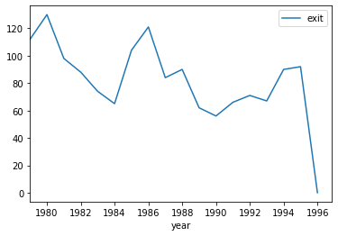

```python
df2.plot('year', xlim = 1979)
```